# Lecture 15: Classification

2016/12/21

# Classification

## RMD_example 15.1: Read 部落格分類 data

```r
# Get the file url for training data
fileurl = 'http://ghuang.stat.nctu.edu.tw/course/statmethods16/files/data/blogtrain.csv'
# Import the csv file into R
#   note: stringsAsFactors=TRUE will screw up conversion to numeric!
blogtrain<-read.csv(fileurl, header=TRUE, stringsAsFactors=FALSE)
#   note: read.csv treats the 1st column of blogtrain.csv as the data, not the rownames,
#         we have to correct this
#         get the 1st column as the rownames
names1<-blogtrain[,1]
#         remove the 1st column from blogtrain
blogtrain<-blogtrain[,-1]
#         assign the rownames
rownames(blogtrain)<-names1
colnames(blogtrain)
```

```
## [1] "commentscount"   "articlescount"   "usagedays"       "subscribercount"
## [5] "cateid"
```

```r
dim(blogtrain)
```

```
## [1] 1948    5
```

```r
head(blogtrain)
```

```
##   commentscount articlescount usagedays subscribercount cateid
## 1         15648          2756      2638             161      0
## 2         18876          3075      3545            2254      0
## 3         24614          1465       229             417      0
## 4         18426           583      1494             101      0
## 5         15854          1390      2639             757      0
## 6         14624          1856      2285             487      0
```

```r
# Get the file url for testing data
fileurl = 'http://ghuang.stat.nctu.edu.tw/course/statmethods16/files/data/blogtest.csv'
# Import the csv file into R
#   note: stringsAsFactors=TRUE will screw up conversion to numeric!
blogtest<-read.csv(fileurl, header=TRUE, stringsAsFactors=FALSE)
#   note: read.csv treats the 1st column of blogtest.csv as the data, not the rownames,
#         we have to correct this
#         get the 1st column as the rownames
names2<-blogtest[,1]
#         remove the 1st column from blogtest
blogtest<-blogtest[,-1]
#         assign the rownames
rownames(blogtest)<-names2
colnames(blogtest)
```

```
## [1] "commentscount"   "articlescount"   "usagedays"       "subscribercount"
## [5] "cateid"
```

```r
dim(blogtest)
```

```
## [1] 3 5
```

```r
head(blogtest)
```

```
##      commentscount articlescount usagedays subscribercount cateid
## 1949         20422          1878      3484             677      0
## 1950         20823          3636      2677            1873      1
## 1951         97965          4511      2109            8679      2
```

## RMD_example 15.2: Linear discriminant analysis (LDA)

We firt “train” the model using `blogtrain`.

```r
# Install package "MASS" first, then load it into R
library(MASS)

# Create model formula with all variables as predictors
xname<-colnames(blogtrain)[-5]
(fmla <- as.formula(paste("as.factor(cateid) ~ ", paste(xname, collapse= "+"))))
```

```
## as.factor(cateid) ~ commentscount + articlescount + usagedays +
##     subscribercount
```

```r
fitlda<-lda(fmla, prior=c(1/3,1/3,1/3), data=blogtrain, na.action="na.omit")

# Show the results
fitlda
```

```
## Call:
## lda(fmla, data = blogtrain, prior = c(1/3, 1/3, 1/3), na.action = "na.omit")
##
## Prior probabilities of groups:
##         0         1         2
## 0.3333333 0.3333333 0.3333333
##
## Group means:
##   commentscount articlescount usagedays subscribercount
## 0     1942.8122      580.6543  1590.488        219.3115
## 1     1945.8557      549.5644  1773.506        225.4696
## 2      625.4833      552.8141  1706.329        102.9145
##
## Coefficients of linear discriminants:
##                           LD1           LD2
## commentscount    0.0001772913  1.897259e-05
## articlescount   -0.0001089656 -8.468020e-05
## usagedays       -0.0001529691  1.188610e-03
## subscribercount  0.0011830598  1.029814e-04
##
## Proportion of trace:
##    LD1    LD2
## 0.7958 0.2042
```

We can plot each observation in the space of the first 2 linear discriminants using the following codes. Points are identified with the class label.

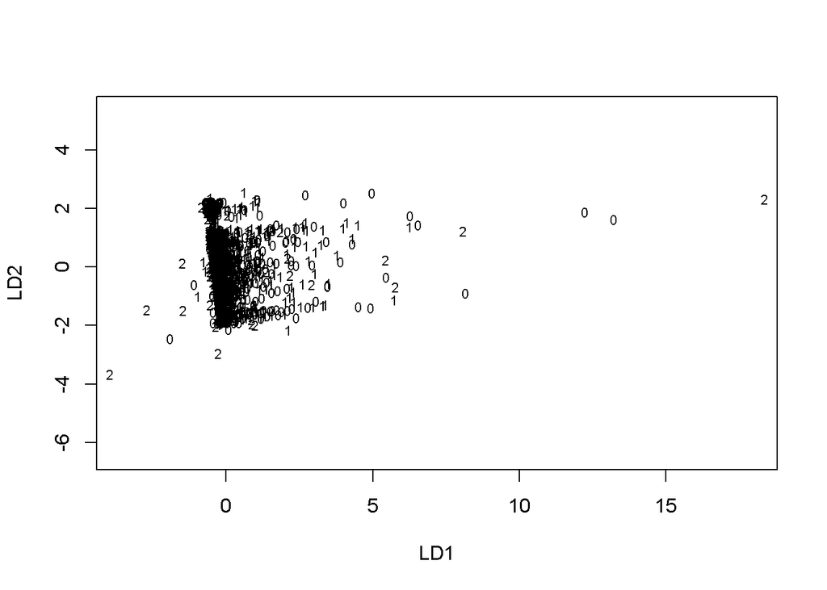

```r
plot(fitlda)
```

A nice way of displaying the results of a LDA is to make a stacked histogram of the values of the discriminant function for the objects from different classes.

We can do this using the `ldahist()` function in R. For example, to make a stacked histogram of the 1st discriminant function’s values for objects of the three different `catei` classes, we type:

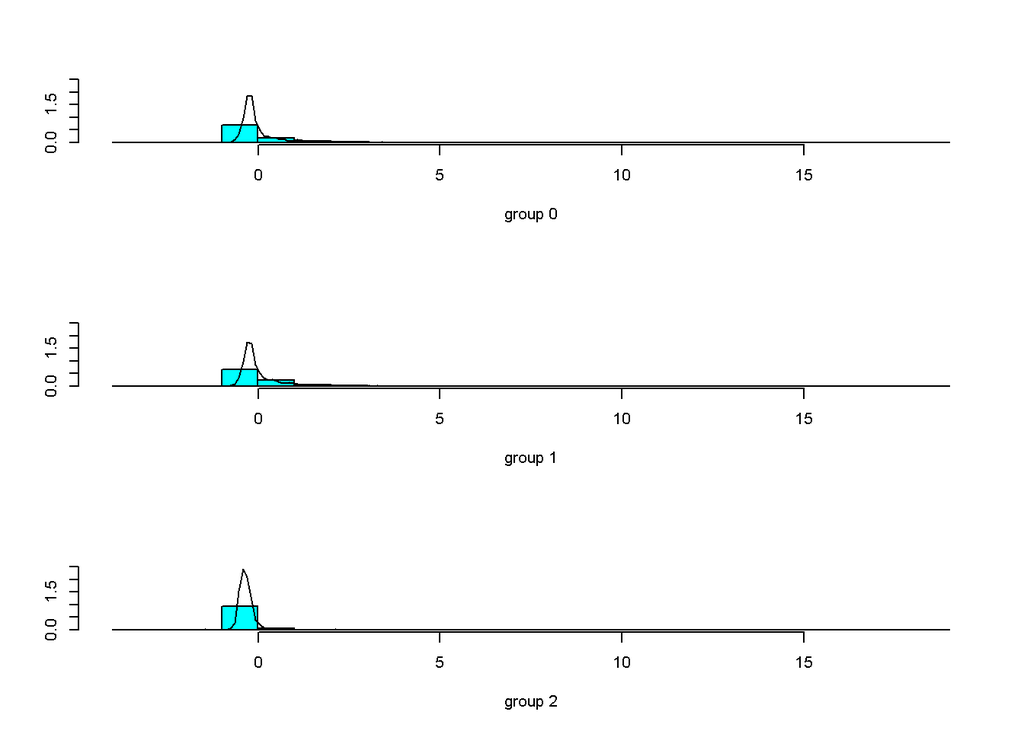

```r
lda.pred <- predict(fitlda)
ldahist(lda.pred$x[,1], g=blogtrain$cateid, type="both")
```

A stacked histogram of the 2nd discriminant function’s values for objects of the three different `catei` classes:

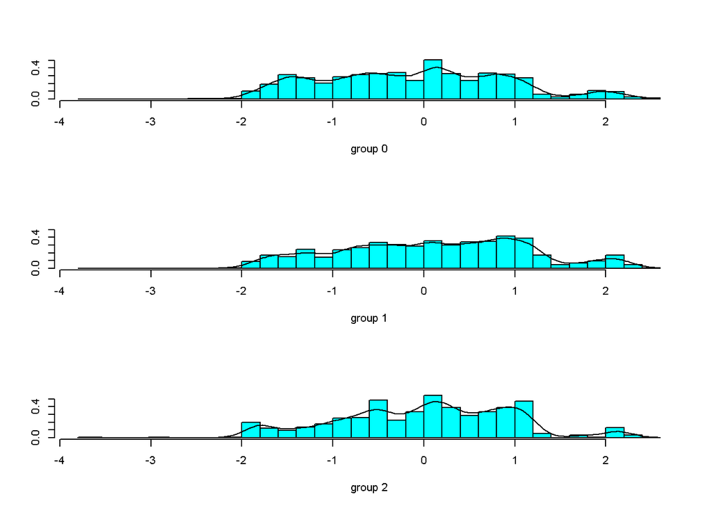

```r
ldahist(lda.pred$x[,2], g=blogtrain$cateid, type="both")
```

The `partimat( )` function in the `klaR` package can display the results of a linear classifications 2 variables at a time.

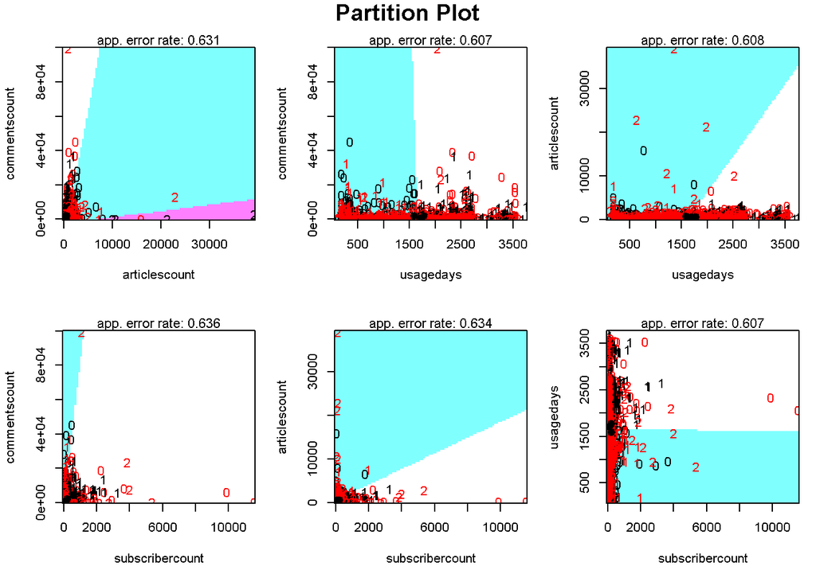

```r
# Install package "klaR" first, then load it into R
library(klaR)
partimat(fmla, data=blogtrain, method="lda")
```

Assess the accuracy of the prediction from leave-one-out cross-validation

```r
fitldac<-lda(fmla, prior=c(1/3,1/3,1/3), data=blogtrain, na.action="na.omit", CV=TRUE)
ct<-table(blogtrain$cateid, fitldac$class)
ct
```

```
##
##       0   1   2
##   0 270 181 252
##   1 239 232 236
##   2 117  51 370
```

```r
# Total percent correct from leave-one-out cross-validation
sum(diag(prop.table(ct)))
```

```
## [1] 0.4476386
```

Then, assess the accuracy of the prediction using the independent testing set `blogtest`

```r
fitlda<-lda(fmla, prior=c(1/3,1/3,1/3), data=blogtrain, na.action="na.omit")
btest<-blogtest[,-5]
testcl<-predict(fitlda, btest)$class
testcl
```

```
## [1] 1 1 1
## Levels: 0 1 2
```

```r
cttl<-table(blogtest$cateid, testcl)
cttl
```

```
##    testcl
##     0 1 2
##   0 0 1 0
##   1 0 1 0
##   2 0 1 0
```

```r
# Total percent correct from the testing set
sum(diag(prop.table(cttl)))
```

```
## [1] 0.3333333
```

## RMD_example 15.3: Quadratic discriminant analysis (QDA)

“Train” the model using `blogtrain`.

```r
# Create model formula with all variables as predictors
xname<-colnames(blogtrain)[-5]
(fmla <- as.formula(paste("as.factor(cateid) ~ ", paste(xname, collapse= "+"))))
```

```
## as.factor(cateid) ~ commentscount + articlescount + usagedays +
##     subscribercount
```

```r
fitqda<-qda(fmla, prior=c(1/3,1/3,1/3), data=blogtrain, na.action="na.omit")

# Show the results
fitqda
```

```
## Call:
## qda(fmla, data = blogtrain, prior = c(1/3, 1/3, 1/3), na.action = "na.omit")
##
## Prior probabilities of groups:
##         0         1         2
## 0.3333333 0.3333333 0.3333333
##
## Group means:
##   commentscount articlescount usagedays subscribercount
## 0     1942.8122      580.6543  1590.488        219.3115
## 1     1945.8557      549.5644  1773.506        225.4696
## 2      625.4833      552.8141  1706.329        102.9145
```

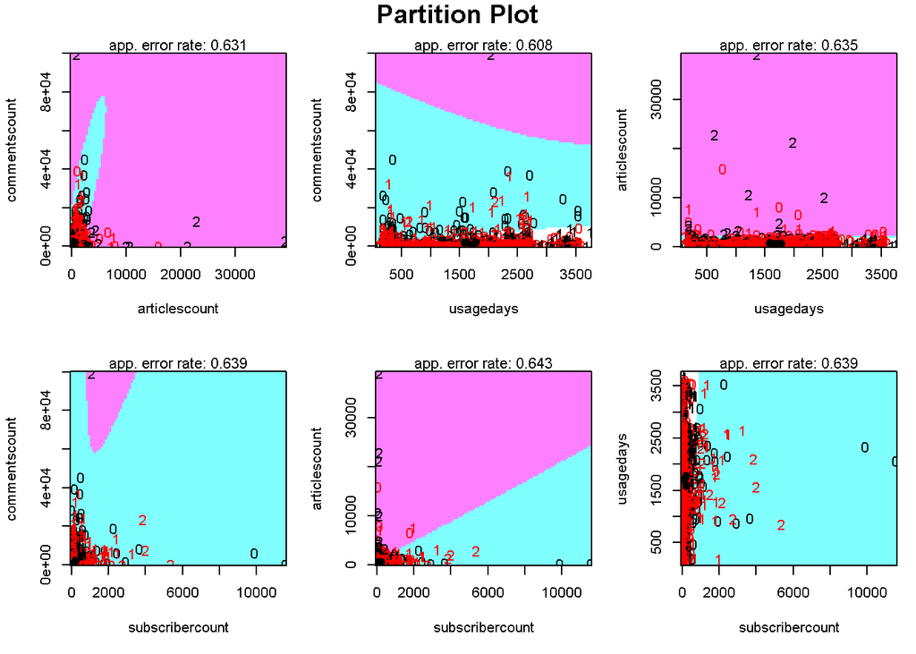

```r
# Display the results of a quadratic classifications 2 variables at a time.
#   Install package "klaR" first, then load it into R
library(klaR)
partimat(fmla, data=blogtrain, method="qda")
```

```r
# Assess the accuracy of the prediction from leave-one-out cross-validation
fitqdac<-qda(fmla, prior=c(1/3,1/3,1/3), data=blogtrain, na.action="na.omit", CV=TRUE)
ct<-table(blogtrain$cateid, fitqdac$class)
ct
```

```
##
##       0   1   2
##   0  55 622  26
##   1  59 628  20
##   2  13 503  22
```

```r
# Total percent correct from leave-one-out cross-validation
sum(diag(prop.table(ct)))
```

```
## [1] 0.3619097
```

Assess the accuracy of the prediction using the independent testing set `blogtest`

```r
fitqda<-qda(fmla, prior=c(1/3,1/3,1/3), data=blogtrain, na.action="na.omit")
btest<-blogtest[,-5]
testcq<-predict(fitqda, btest)$class
testcq
```

```
## [1] 0 0 0
## Levels: 0 1 2
```

```r
cttq<-table(blogtest$cateid, testcq)
cttq
```

```
##    testcq
##     0 1 2
##   0 1 0 0
##   1 1 0 0
##   2 1 0 0
```

```r
# Total percent correct from the testing set
sum(diag(prop.table(cttq)))
```

```
## [1] 0.3333333
```